# Trabalho Final - Técnicas Multivariadas Aplicadas a Dados de COVID-19

Análise Multivariada - 2026.1

Autor

Milena Paz Freitas

# Introdução

O conjunto de dados foi compilado pelos autores de Artes; Barroso (2023), e inclui dados públicos da época da pandemia por COVID-19 (cerca de 2020) nos estados de São Paulo e Minas Gerais. Neste trabalho, munida de diversas técnicas de análise de dados multivariados apresentados durante o curso, será feita uma exploração desse mesmo banco usando o software R. Segue um dicionário das variáveis presentes:

- **Município:** Nome do município
- **Estado:** Estado do município
- **Casos:** Número de casos de COVID-19 em 01/10/2020
- **Óbitos:** Número de óbitos por COVID-19 EM 01/10/2020
- **População:** População estimada em 2020
- **IDHM:** Índice de Desenvolvimento Humanao Municipal em 2010
- **IDHR:** IDHM Renda em 2010
- **IDHL:** IDHM Longevidade em 2010
- **IDHE:** IDHM Educação em 2010
- **Prevalência:** Número de casos dividido pela população × 100.000
- **Mortalidade:** Número de óbitos dividido pela população × 100.000
- **Letalidade:** Número de óbitos dividido pelo número de casos × 100%

# 1. Análise exploratória inicial

Serão feitas medidas-resumo e análise gráfica das variáveis a nível individual, além de verificar presença de `NA`s. Primeiramente, a leitura e limpeza dos dados:

```r
covid=readxl::read_excel("Covid19MGSP.xlsx")
covid$IDHR <- as.numeric(covid$IDHR)
```

A linha 216 da coluna IDHR no arquivo estava como “0,673td>”, fazendo com que a variável fosse lida como caractere e assim foi convertido para `NA` em `as.numeric()`. Corrigindo:

```r
covid$IDHR[216] <- 0.673
covid$Estado <- as.factor(covid$Estado)
#verificando NAs
sum(is.na(covid))
```

```
[1] 0
```

```r
#Não temos NAs, ótimo!
covid <- as.data.frame(covid)
```

O conjunto de dados não possui valores faltantes, o que é preferível. Explorando os dados:

**Código**

```r
summary(covid[-1])
```

```
 Estado       Casos              Óbitos           População
 MG:853   Min.   :     0.0   Min.   :    0.00   Min.   :     776
 SP:645   1st Qu.:    32.0   1st Qu.:    1.00   1st Qu.:    5027
          Median :    96.0   Median :    2.00   Median :   10190
          Mean   :   859.9   Mean   :   28.82   Mean   :   45115
          3rd Qu.:   356.0   3rd Qu.:    8.00   3rd Qu.:   25243
          Max.   :293210.0   Max.   :12797.00   Max.   :12325232
      IDHM             IDHR             IDHL             IDHE
 Min.   :0.5290   Min.   :0.5020   Min.   :0.7230   Min.   :0.3390
 1st Qu.:0.6610   1st Qu.:0.6422   1st Qu.:0.8100   1st Qu.:0.5460
 Median :0.7060   Median :0.6870   Median :0.8300   Median :0.6160
 Mean   :0.6987   Mean   :0.6797   Mean   :0.8291   Mean   :0.6083
 3rd Qu.:0.7390   3rd Qu.:0.7200   3rd Qu.:0.8488   3rd Qu.:0.6760
 Max.   :0.8620   Max.   :0.8910   Max.   :0.8900   Max.   :0.8250
  Prevalência      Mortalidade        Letalidade
 Min.   :   0.0   Min.   :  0.000   Min.   :  0.0000
 1st Qu.: 526.4   1st Qu.:  7.725   1st Qu.:  0.7884
 Median :1030.2   Median : 24.142   Median :  2.2026
 Mean   :1277.6   Mean   : 31.437   Mean   :  2.9483
 3rd Qu.:1700.6   3rd Qu.: 44.758   3rd Qu.:  3.6496
 Max.   :8988.6   Max.   :246.914   Max.   :100.0000
```

**Código**

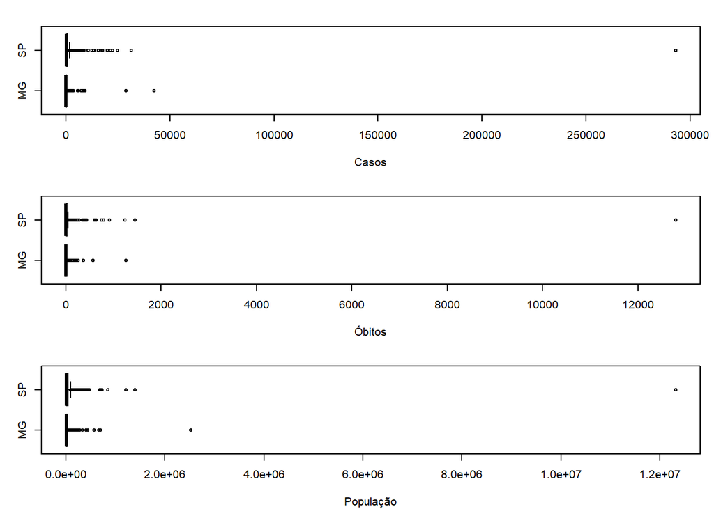

```r
#Análise Gráfica
cores=c("darkorange","blue3")
par(mar=c(4.1,3.1,2,1),mfrow=c(3,1))
boxplot(Casos~Estado,data=covid,col=cores,horizontal=T)
boxplot(Óbitos~Estado,data=covid,col=cores,horizontal=T)
boxplot(População~Estado,data=covid,col=cores,horizontal=T)
```

Quanto ao número de óbitos, casos de COVID e população municipal, os estados não se diferenciam muito entre si; só vemos mais outliers no estado de SP (a metrópole São Paulo sendo destacada à direita). Veremos, agora, quanto às características de desenvolvimento de cada município:

**Código**

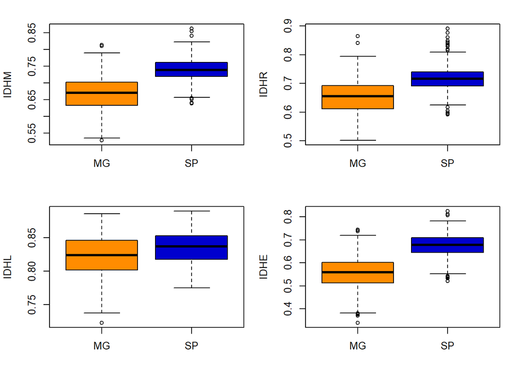

```r
par(mar=c(3.1,4.1,2,1),mfrow=c(2,2))
boxplot(IDHM~Estado,data=covid,col=cores)
boxplot(IDHR~Estado,data=covid,col=cores)
boxplot(IDHL~Estado,data=covid,col=cores)
boxplot(IDHE~Estado,data=covid,col=cores)
```

Minas Gerais parece ter maior variação em termos de desenvolvimento humano que São Paulo. Isso é esperado, já que o estado de SP é conhecido pelo alto desenvolvimento e produto interno bruto em relação aos demais. Quanto à epidemiologia da cidade, temos:

**Código**

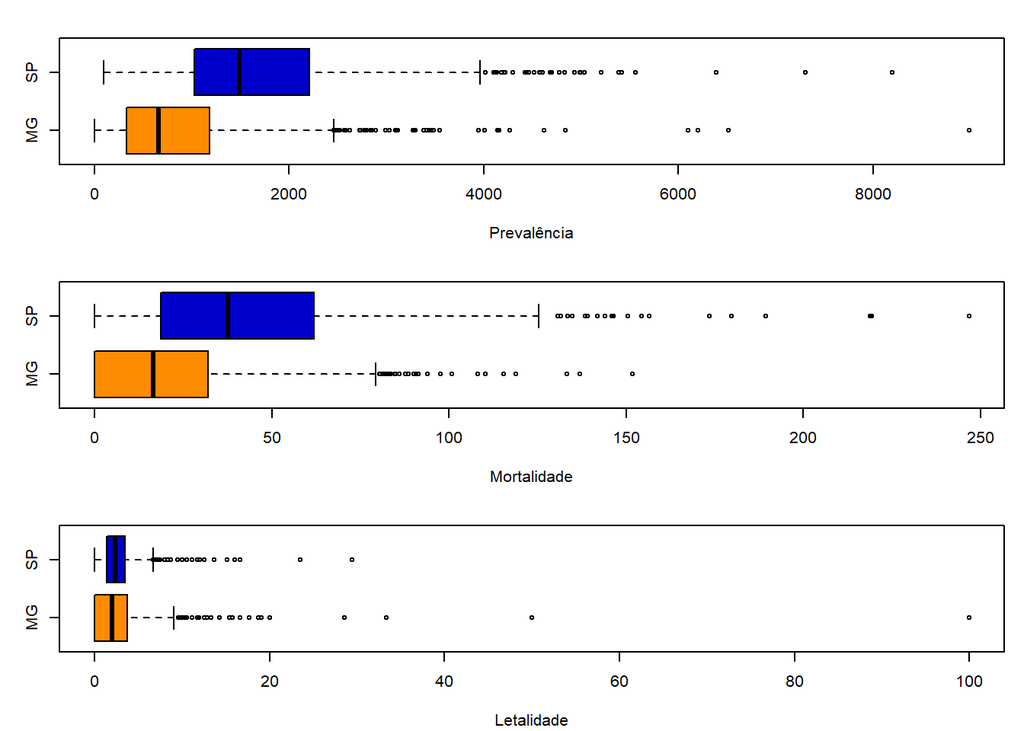

```r
par(mar=c(4.1,3.1,2,1),mfrow=c(3,1))
boxplot(Prevalência~Estado,data=covid,col=cores,horizontal=T)
boxplot(Mortalidade~Estado,data=covid,col=cores,horizontal=T)
boxplot(Letalidade~Estado,data=covid,col=cores,horizontal=T)
```

Os estados estão próximos em Letalidade mas, em Prevalência e Mortalidade, o estado de São Paulo parece ser mais afetado. A seguir faremos uma matriz de gráficos de dispersão, identificando os estados pela cor dos pontos:

**Código**

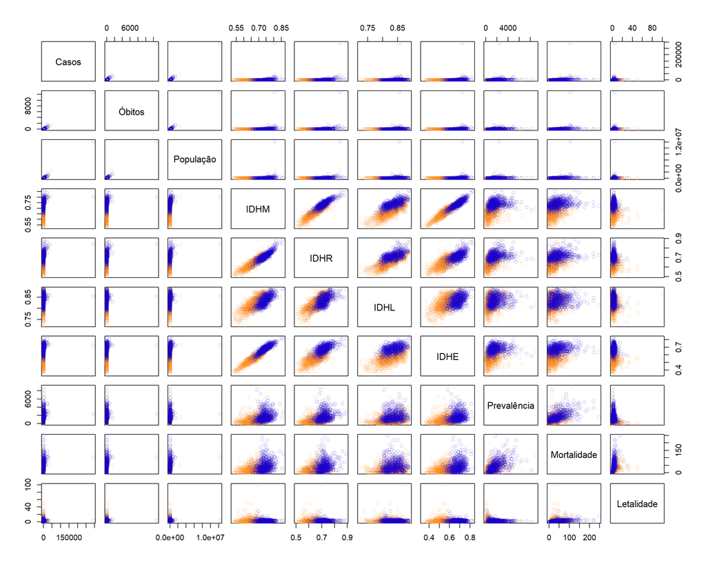

```r
cores=c("#FC8D2330","#1700CB30")
par(mar=c(3.1,3.1,1,1))
plot(covid[-c(1,2)],col=cores[as.numeric(covid$Estado)])
```

As variáveis de desenvolvimento parece ter certa elipsidade entre si e melhor distinção entre os grupos, abrindo possibilidade de classificação.

# 2. Análise de Componentes Principais

Faremos uma análise de componentes principais usando todas as variáveis numéricas. Pela diferença de grandeza ser tão grande entre as variáveis (por exemplo, verificar as médias de População e qualquer subtipo de IDH) usaremos a matriz de correlações para esse fim.

**Código**

```r
x=as.matrix(covid[-c(1,2)])
colnames(x) <- c("Casos","Obitos","Pop","IDHM","IDHR","IDHL","IDHE","Prev","Mort","Let")
#matriz de correlacoes
round(R <- cor(x),2)
```

```
       Casos Obitos  Pop  IDHM  IDHR  IDHL  IDHE  Prev Mort   Let
Casos   1.00   0.99 0.99  0.15  0.18  0.09  0.13  0.11 0.15  0.01
Obitos  0.99   1.00 0.99  0.12  0.15  0.07  0.10  0.08 0.14  0.02
Pop     0.99   0.99 1.00  0.15  0.18  0.09  0.13  0.08 0.14  0.01
IDHM    0.15   0.12 0.15  1.00  0.93  0.71  0.95  0.43 0.37 -0.06
IDHR    0.18   0.15 0.18  0.93  1.00  0.72  0.79  0.44 0.37 -0.06
IDHL    0.09   0.07 0.09  0.71  0.72  1.00  0.53  0.27 0.20 -0.03
IDHE    0.13   0.10 0.13  0.95  0.79  0.53  1.00  0.39 0.36 -0.05
Prev    0.11   0.08 0.08  0.43  0.44  0.27  0.39  1.00 0.59 -0.13
Mort    0.15   0.14 0.14  0.37  0.37  0.20  0.36  0.59 1.00  0.31
Let     0.01   0.02 0.01 -0.06 -0.06 -0.03 -0.05 -0.13 0.31  1.00
```

**Código**

```r
#dados padronizados
z=scale(x)
# vamos usar SVD por possuir maior estabilidade numerica que eigen()
Rsvd <- svd(R)
lambda=Rsvd$d
E=Rsvd$u
```

Assim, esses são os autovalores obtidos:

**Código**

```r
round(lambda,2)
```

```
 [1] 4.06 2.74 1.29 0.98 0.49 0.27 0.16 0.01 0.01 0.00
```

E autovetores:

**Código**

```r
round(E,2)
```

```
       [,1]  [,2]  [,3]  [,4]  [,5]  [,6]  [,7]  [,8]  [,9] [,10]
 [1,] -0.26 -0.51  0.03  0.01  0.01  0.03  0.01  0.19  0.79  0.02
 [2,] -0.25 -0.52  0.03  0.00  0.01  0.00  0.03  0.59 -0.56 -0.02
 [3,] -0.26 -0.51  0.05 -0.02  0.00  0.00  0.01 -0.78 -0.23  0.01
 [4,] -0.44  0.23  0.13 -0.14 -0.22  0.03  0.03  0.02 -0.02  0.82
 [5,] -0.43  0.20  0.12 -0.11  0.01  0.03 -0.81  0.01  0.00 -0.29
 [6,] -0.34  0.20  0.20 -0.27  0.77 -0.11  0.34  0.00  0.00 -0.11
 [7,] -0.40  0.21  0.10 -0.10 -0.56  0.05  0.47  0.00  0.02 -0.48
 [8,] -0.28  0.13 -0.29  0.65  0.20  0.60  0.07 -0.01 -0.03  0.00
 [9,] -0.26  0.07 -0.64  0.21  0.01 -0.68  0.01 -0.01  0.01  0.00
[10,]  0.01 -0.03 -0.64 -0.65  0.01  0.40 -0.01  0.00  0.00  0.00
```

Daqui, podemos ver que a primeira componente é muito geral e não possui interpretabilidade. A segunda parece dar leve contraste entre características demográficas e de desenvolvimento humano. No geral, não é muito interessante analisá-las.

# 3. Verificação de Normalidade

Para realizar as próximas técnicas é interessante saber se os dados são normalmente distribuídos; por exemplo, técnicas de classificação e discriminação que utilizam verossimilhança (no R, pelo pacote `MASS`, são QDA e LDA). Assim, podemos verificar das seguintes formas:

## Normalidade Univariada

Faremos Q-Q plots para todas as variáveis e testes Shapiro-Wilk, Anderson-Darling e Lilliefors ao nível de 5%. Os p-valores arrendondados para 4 casas estarão escritos sobre o gráfico quantil-quantil. Primeiramente, para o estado de São Paulo:

**Código**

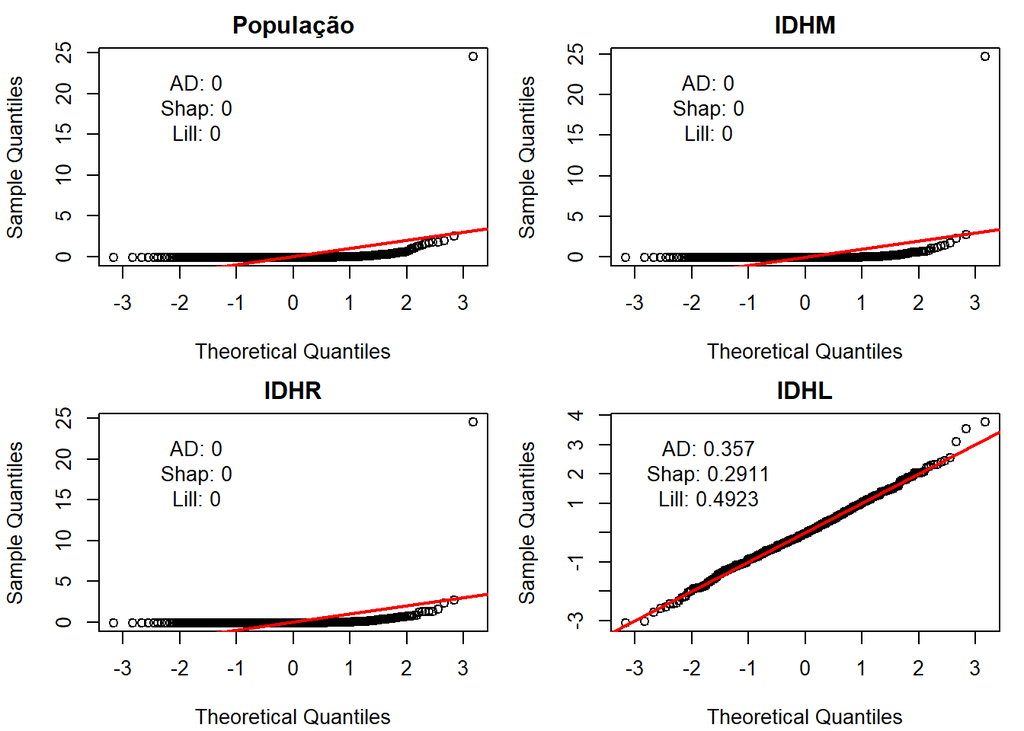

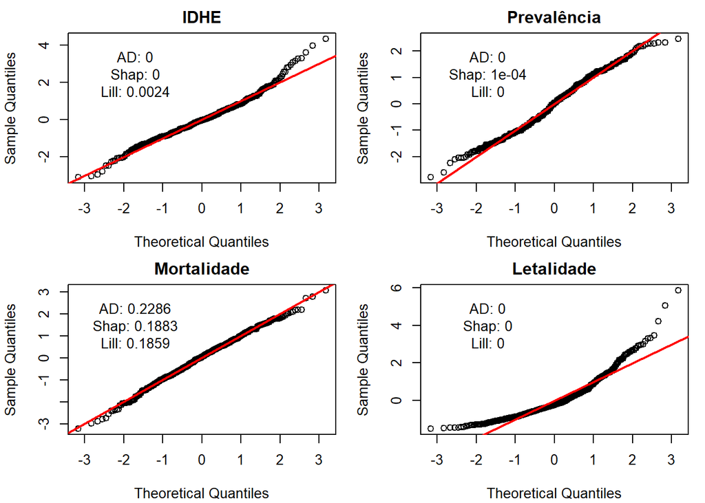

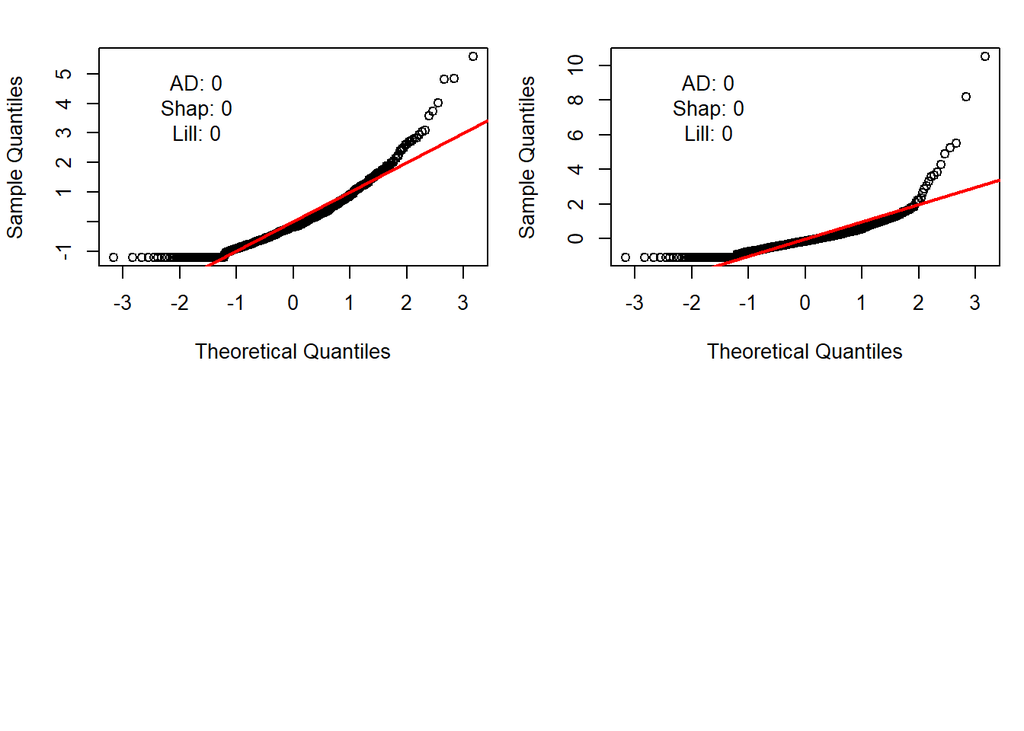

```r
library(nortest)
par(mfrow=c(2,2),mar=c(4.1,4.1,2,1))
normal1d <- function(i,estado){
  x=covid[covid$Estado==estado,i]
  qqnorm(scale(x), main=names(covid)[i+2])
  abline(a=0,b=1,col="red",lwd=2)
  pvalores <- c(ad.test(x)$p.value,  shapiro.test(x)$p.value,  lillie.test(x)$p.value) |> round(4)
  mtext(paste0("AD: ",pvalores[1],"\n",
               "Shap: ",pvalores[2],"\n",
               "Lill: ",pvalores[3],"\n"),line=-5,at=-1.7,cex=0.85)
}
invisible(sapply(3:12,normal1d,estado="SP"))
```

Assim, temos que apenas o IDHL e a mortalidade parecem ser normais univariadas no estado de SP. No estado de MG:

**Código**

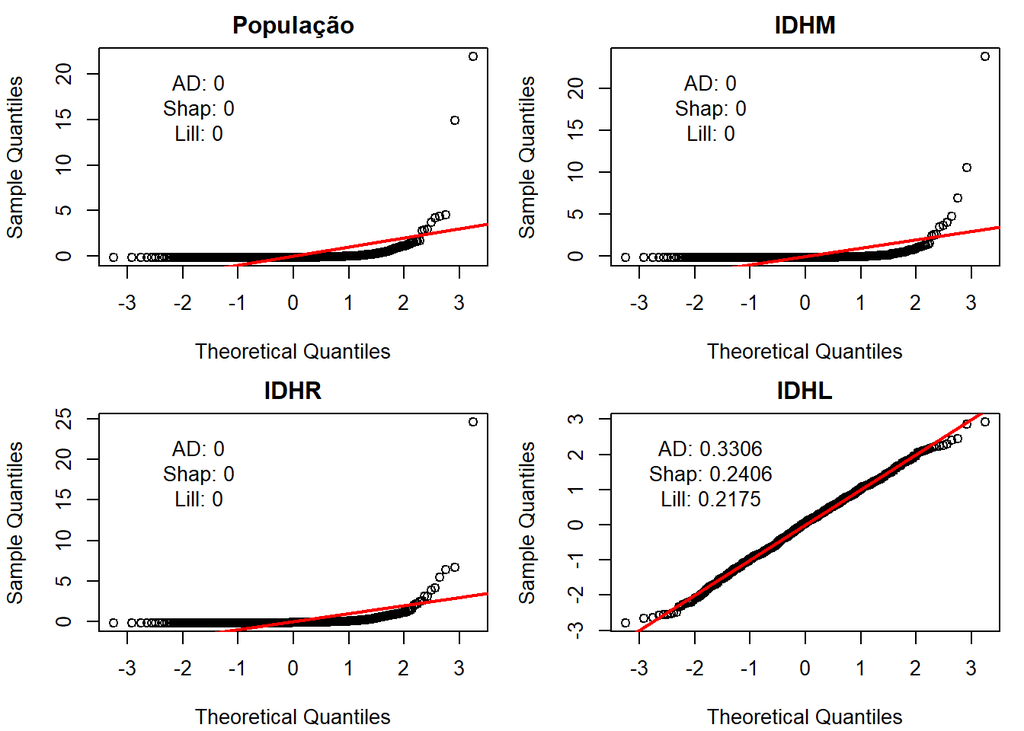

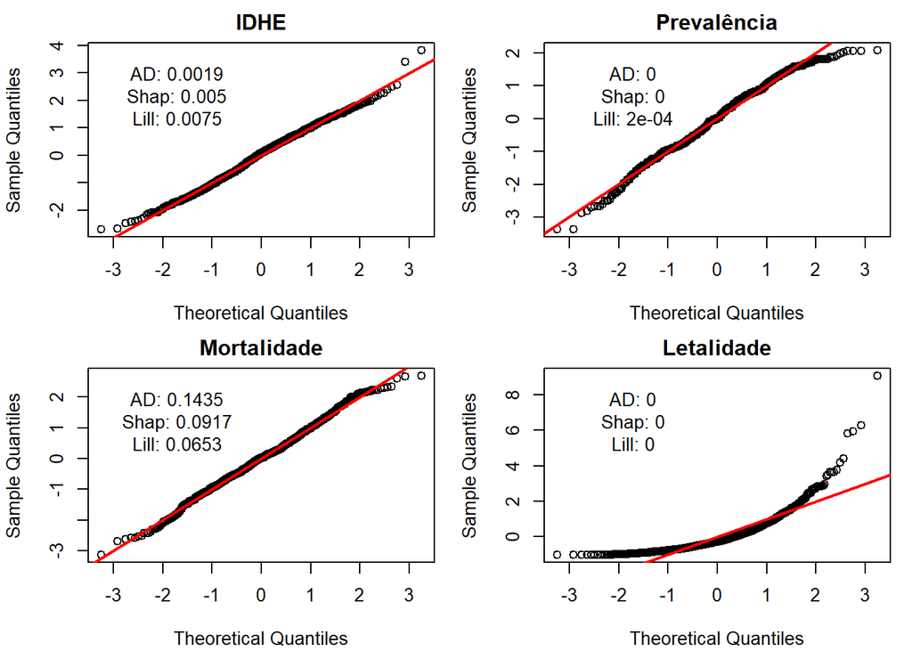

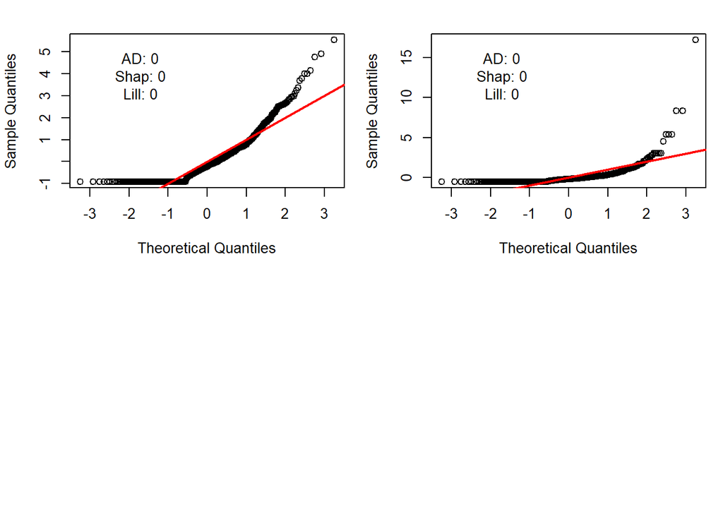

```r
par(mfrow=c(2,2),mar=c(4.1,4.1,2,1))
invisible(sapply(3:12,normal1d,estado="MG"))
```

O mesmo ocorreu no estado de MG.

## Normalidade Bivariada

Será feito graficamente verificação da elipsidade dos pares de variáveis, com as elipses de 95% em vermelho e as de 50% em azul desenhadas.

**Código**

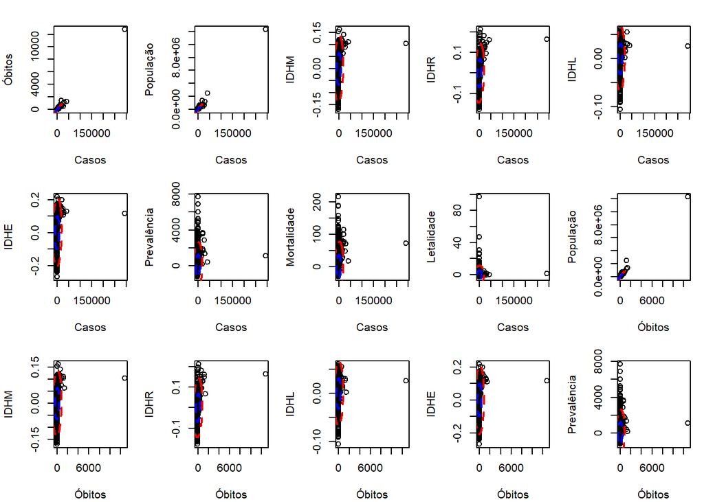

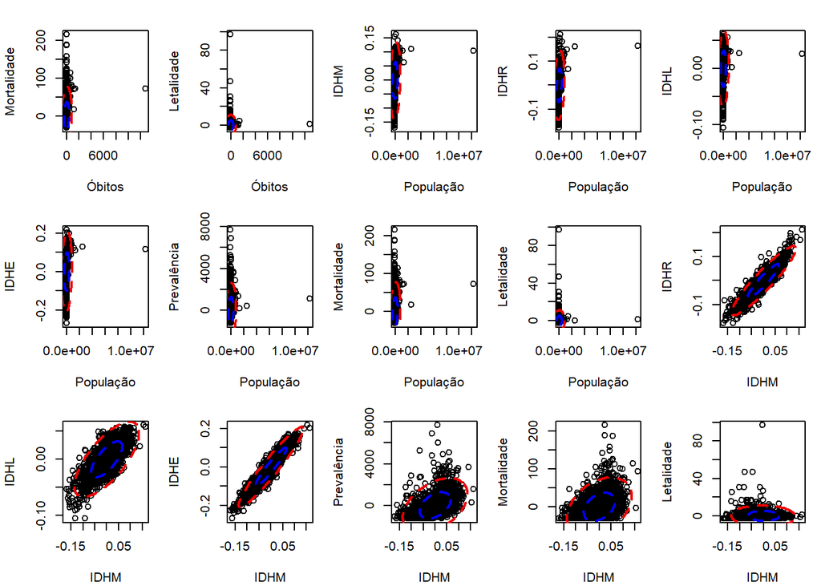

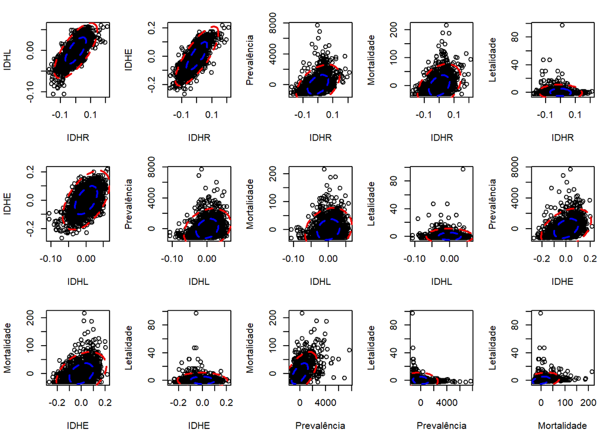

```r
par(mfrow=c(3,5),mar=c(4.1,4.1,2,1))
pares <- combn(10,2)
Xc <- scale(x,scale=F)
grafico <- function(i,j){ #GRAFICO DE DISPERSAO
  plot(medidas[[paste0("X",i)]],medidas[[paste0("X",j)]],
       xlab=paste0("X",i),ylab=paste0("X",j))
}
Sij <- function(i,j){#COVARIANCIAS
  cov(Xc[,c(i,j)])
}
dj2 <- function(ij){
  diag(Xc[,ij]%*%solve(Sij(ij[1],ij[2]))%*%t(Xc[,ij]))
}
#qui-quadrado p/ identificar outliers
out <-apply(pares,2,function(ij){
  which(dj2(ij) > qchisq(0.95,df=2))
  })
library(ellipse)
#GRAFICO CENTRADO
graficoC <- function(i,j){
  plot(Xc[,i],Xc[,j],
       xlab=names(covid)[i+2],ylab=names(covid)[j+2])
}
## ELIPSES 95%
invisible(apply(pares,2,function(ij){
  graficoC(ij[1],ij[2])
  disp <- Xc[,ij]
  points(disp[out[[paste0(ij,collapse = "")]],],pch=19,col="maroon")
  elip <- ellipse(cor(disp)[1,2],level=0.95,scale=apply(disp,2,sd),
                  centre=colMeans(disp))
  lines(elip,col="red2",lty=2,lwd=2)
  elip50 <- ellipse(cor(disp)[1,2],level=0.5,scale=apply(disp,2,sd),
                  centre=colMeans(disp))
  lines(elip50,col="blue",lty=2,lwd=2)
  }))
```

Visualmente os pares envolvendo os IDHs parecem ter mais definida elipsicidade.

# 4. Análise Fatorial

Usando análise fatorial por verossimilhança (já que a análise de componentes principais não gerou bons resultados), temos os seguintes resultados sem rotação:

**Código**

```r
fa <- factanal(z,factors=6,rotation="none")
fa
```

```
Call:
factanal(x = z, factors = 6, rotation = "none")

Uniquenesses:
 Casos Obitos    Pop   IDHM   IDHR   IDHL   IDHE   Prev   Mort    Let
 0.005  0.007  0.010  0.005  0.005  0.005  0.005  0.005  0.005  0.739

Loadings:
       Factor1 Factor2 Factor3 Factor4 Factor5 Factor6
Casos   0.349   0.933
Obitos  0.320   0.942
Pop     0.346   0.930
IDHM    0.944  -0.203  -0.204          -0.154
IDHR    0.915  -0.159  -0.177                  -0.318
IDHL    0.727  -0.198  -0.339   0.114   0.531   0.132
IDHE    0.866  -0.194  -0.153          -0.388   0.183
Prev    0.594           0.648  -0.436   0.158
Mort    0.550           0.708   0.436
Let                     0.157   0.484

               Factor1 Factor2 Factor3 Factor4 Factor5 Factor6
SS loadings      4.006   2.775   1.168   0.630   0.482   0.153
Proportion Var   0.401   0.278   0.117   0.063   0.048   0.015
Cumulative Var   0.401   0.678   0.795   0.858   0.906   0.921

The degrees of freedom for the model is 0 and the fit was 1.7851
```

Usando 5 fatores ou menos temos rejeição da hipótese de suficiência de número de fatores. Daqui, temos que as loadings são de difícil interpretação: os dois primeiros fatores são muito gerais; o segundo parece indicar demografia, quantidade de pessoas; o terceiro relaciona a prevalência com mortalidade (relação óbvia, o número de mortes por COVID está diretamente relacionado com o número de casos); o quarto contradiz o anterior; os demais fatores não tem interpretação.

Assim, vê-se necessário usar uma rotação. Por Varimax:

**Código**

```r
print(L <- loadings(varimax(loadings(fa))),cutoff=0.32)
```

```
Loadings:
       Factor1 Factor2 Factor3 Factor4 Factor5 Factor6
Casos           0.994
Obitos          0.995
Pop             0.991
IDHM    0.942
IDHR    0.829                           0.324  -0.388
IDHL    0.491                           0.864
IDHE    0.968
Prev                    0.959
Mort                    0.597   0.748
Let                             0.502

               Factor1 Factor2 Factor3 Factor4 Factor5 Factor6
SS loadings      2.899   2.990   1.388   0.818   0.935   0.184
Proportion Var   0.290   0.299   0.139   0.082   0.093   0.018
Cumulative Var   0.290   0.589   0.728   0.809   0.903   0.921
```

Daqui temos que o primeiro fator parece ser um indicador de desenvolvimento; o segundo e terceiro fatores mantêm a mesma interpretação; o quarto fator relaciona a letalidade à mortalidade, sendo um fator de risco de morte; o quinto e sexto não parecem relevantes.

O escore (método de regressão) das cidades Juiz de Fora e São Paulo, por exemplo, são:

**Código**

```r
z0 <- z[c(419,1418),]
Psi=diag(fa$uniquenesses)
R6 <- tcrossprod(L)+Psi
escoreBH<- (t(L)%*%solve(R6)%*%z0[1,])
escoreSP<- (t(L)%*%solve(R6)%*%z0[2,])
colnames(escoreBH) <- "Juiz de Fora"
colnames(escoreSP) <- "São Paulo"
escoreBH
```

```
        Juiz de Fora
Factor1    1.5928480
Factor2    0.7536913
Factor3   -0.6704977
Factor4    0.1141512
Factor5   -0.2748022
Factor6   -1.5028224
```

**Código**

```r
escoreSP
```

```
         São Paulo
Factor1 -0.8188565
Factor2 37.1586317
Factor3 -0.4497331
Factor4 -0.6777017
Factor5  0.1822779
Factor6  0.8724474
```

Os escores dos dois primeiros fatores refletem bem a diferença de densidade populacional das cidades e qualidade de vida.

# 5. Modelo de Classificação

A matriz de dispersão feita durante a análise exploratória evidencia certa difernciação entre as características das cidades do estado de MG e de SP. Suponha que tenhamos o nome da cidade, mas não a qual estado ela pertence. Entre os estados há 5 nomes de cidades que existem tanto no estado de MG, quanto em SP. Vamos tentar classificá-las por estado usando os dados disponíveis. São esses nomes: Itapeva, Presidente Bernardes, São Francisco, Tapiraí e Turmalina.

Separaremos essas cidades com nomes duplicados como conjunto de teste e as demais serão usadas para treinamento do modelo. Selecionaremos as variáveis Prevalência, Mortalidade e os IDH’s para essa modelagem, como segue:

**Código**

```r
covid2 <- covid[,c(2,6:11)]
duplicados=c("Itapeva","Presidente Bernardes","São Francisco","Tapiraí","Turmalina")
teste=covid2[which(covid$Município%in%duplicados),]
treino=covid2[which(!covid$Município%in%duplicados),]

cov.l <- lapply(c("MG","SP"), function(y)
  cov(treino[treino$Estado==y,-1],use="na.or.complete")
)
```

Estrutura de covariâncias de MG e SP, respectivamente:

**Código**

```r
lapply(cov.l,round,3)
```

```
[[1]]
              IDHM   IDHR  IDHL   IDHE Prevalência Mortalidade
IDHM         0.002  0.003 0.001  0.003      12.712       0.233
IDHR         0.003  0.003 0.001  0.003      16.798       0.299
IDHL         0.001  0.001 0.001  0.001       6.423       0.111
IDHE         0.003  0.003 0.001  0.005      13.060       0.249
Prevalência 12.712 16.798 6.423 13.060  783170.977   10513.735
Mortalidade  0.233  0.299 0.111  0.249   10513.735     535.821

[[2]]
             IDHM   IDHR  IDHL  IDHE Prevalência Mortalidade
IDHM        0.001  0.001 0.000 0.001       7.861       0.294
IDHR        0.001  0.002 0.001 0.001      11.087       0.377
IDHL        0.000  0.001 0.000 0.000       3.495       0.093
IDHE        0.001  0.001 0.000 0.002       8.296       0.375
Prevalência 7.861 11.087 3.495 8.296 1212518.157   21367.343
Mortalidade 0.294  0.377 0.093 0.375   21367.343    1303.406
```

Faremos um teste M de Box para verificar se as matrizes de covariância são significativamente diferentes ou não.

**Código**

```r
heplots::boxM(treino[,-1],treino[,1])
```

```
 Box's M-test for Homogeneity of Covariance Matrices

data:  treino[, -1] by treino[, 1]
Chi-Sq (approx.) = 1655.659, df = 21, p-value = < 2.2e-16
```

Temos que houve rejeição da hipótese nula de igualdade das estruturas de covariância. Portanto, usaremos o método de QDA para o modelo de classificação. A matriz de confusão para o modelo usando os dados de treino é:

**Código**

```r
modqd <- MASS::qda(Estado~.,data=treino)
pred <- predict(modqd)
(confusao <- table(Predicao=pred$class, Referencia=treino$Estado))
```

```
        Referencia
Predicao  MG  SP
      MG 708  67
      SP 140 573
```

**Código**

```r
#acuracia
ac=sum(diag(confusao)/sum(confusao))
#taxa de erro global
teg=1-ac
#especificidade
esp=confusao[1,1]/sum(confusao[,1])
#sensibilidade
sens=confusao[2,2]/sum(confusao[,2])
```

E temos também as medidas de avaliação:

**Código**

```r
library(kableExtra)
kbl(rbind(Acurácia=ac,"Taxa de Erro Geral"=teg,Especificidade=esp,Sensibilidade=sens))%>%
  kable_styling(full_width = F)%>%
    column_spec(1, bold = T)
```

| Acurácia | 0.8608871 |
| --- | --- |
| Taxa de Erro Geral | 0.1391129 |
| Especificidade | 0.8349057 |
| Sensibilidade | 0.8953125 |

Assim, temos a seguinte matriz de confusão para os dados de teste:

**Código**

```r
pred <- predict(modqd,newdata=teste)
(confusao <- table(Predicao=pred$class, Referencia=teste$Estado))
```

```
        Referencia
Predicao MG SP
      MG  4  1
      SP  1  4
```

Houve apenas 2 erros das 10 classificações feitas. Como o conjunto de teste é pequeno, compararemos lado a lado:

**Código**

```r
kbl(cbind(Cidade=rep(duplicados,2),
          Predição=as.character(pred$class), Referência=as.character(teste$Estado)))%>%
  kable_styling(full_width = F,font_size = 12)%>%
  column_spec(1, bold = T)
```

| Cidade | Predição | Referência |
| --- | --- | --- |
| Itapeva | SP | MG |
| Presidente Bernardes | MG | MG |
| São Francisco | MG | MG |
| Tapiraí | MG | MG |
| Turmalina | MG | MG |
| Itapeva | SP | SP |
| Presidente Bernardes | SP | SP |
| São Francisco | SP | SP |
| Tapiraí | MG | SP |
| Turmalina | SP | SP |

# Considerações Finais

Entre as diferentes técnicas usadas, a que teve resultado mais surpreendente foi a de classificação: o modelo teve desempenho melhor que esperado para predizer a quais estados cada município pertencia. ACP não teve bons resultados, enquanto a análise fatorial (com rotação) teve muito melhor interpretabilidade. No geral, foi uma interessante experiência.

## Referências

ARTES, R.; BARROSO, L. P. **Métodos multivariados de análise estatística**. [s.l.] Blucher, 2023.

JOHNSON, R. A.; WICHERN, D. W. **Applied multivariate statistical analysis**. [s.l.] Prentice hall Upper Saddle River, NJ, 2002.